# Health and Financial Impact of Severe-Weather Events Between 2007 and 2011

# Synopsis

In this analysis we initially intended to explore two questions:

- Across the United States, which types of events are most harmful to population health?
- Across the United States, which types of events have the greatest economic cost?

We sought answers in NOAA Storm Database data from 1950 through 2011. Although this spans more than 60 years, only five years (2007 through 2011) of data were found suitable to comparative analysis, for reasons explained in the *Data Processing* section. Thus we instead explored questions constrained to 2007 through 2011.

We found that tornadoes were unambiguously most harmful in terms of injuries, and also harmful in terms of fatalities. The most harmful events to public health also included excessive heat, flash floods, lightning, rip currents, and thunderstorm winds. The most economically harmful events in terms of property and crop damage included flash floods, floods, frost and freeze, hail, storm surge and tides, and tornadoes.

# Data Processing

We begin by loading required libraries *data.table* and *dplyr* for data manipulation, *lubridate* for handling dates, and *ggplot2* for plotting.

```r
library(data.table)
library(ggplot2)
library(dplyr)
library(lubridate)
```

We set hard-coded analysis parameters, most importantly the raw data URL. The remaining convenience parameters organize analysis files.

```r
# Data subdirectory.
dat_dir <- "data"
# Raw data subdirectory.
raw_dir <- file.path(dat_dir, "raw")
# Intermediate data subdirectory.
int_dir <- file.path(dat_dir, "intermediate")
# Clean data subdirectory.
cln_dir <- file.path(dat_dir, "processed")

# Raw-data URL.
raw_url <- "https://d396qusza40orc.cloudfront.net/repdata%2Fdata%2FStormData.csv.bz2"
# Raw-data filename.
raw_fnm <- "StormData.csv.bz2"
# Raw-data path.
raw_pth <- file.path(raw_dir, raw_fnm)

# Cached data.
cch_fnm <- "StormData.csv"
cch_pth <- file.path(int_dir, cch_fnm)

# Tidy data.
tdy_fnm <- "StormData-Tidy.csv"
tdy_pth <- file.path(cln_dir, tdy_fnm)
```

We create missing analysis subdirectories.

```r
if(!dir.exists(dat_dir)){ dir.create(dat_dir) }
if(!dir.exists(raw_dir)){ dir.create(raw_dir) }
if(!dir.exists(int_dir)){ dir.create(int_dir) }
if(!dir.exists(cln_dir)){ dir.create(cln_dir) }
```

We define a convenience function to load raw data, downloading and caching if missing.

```r
fetch_if_missing_then_load <- function(url_, raw_pth_, dat_pth_){
    if(!file.exists(dat_pth_)){
        if(!file.exists(raw_pth_)){ download.file(url_, raw_pth_) }
        fwrite(read.csv(raw_pth_), dat_pth_)
    }
    fread(dat_pth_)
}
```

We load raw data.

```r
dat <- fetch_if_missing_then_load(raw_url, raw_pth, cch_pth)
```

We will process the following columns. We discard the rest.

- `EVTYPE` (weather-event types)
- `FATALITIES` and `INJURIES`
- `PROPDMG` and `PROPDMGEXP` (property-damage values)
- `CROPDMG` and `CROPDMGEXP` (crop-damage values)
- `BGN_DATE`, `BGN_TIME`, and `TIME_ZONE` (weather-event starting dates and times)

```r
dat <- dat %>%
    select(
        EVTYPE, BGN_DATE, BGN_TIME, TIME_ZONE,
        PROPDMG, PROPDMGEXP, CROPDMG, CROPDMGEXP, FATALITIES, INJURIES
    ) %>%
    data.table()
```

### Initial quality assessment: event types

From section 2.1 of the [National Weather Service (NWS) storm data documentation](https://d396qusza40orc.cloudfront.net/repdata%2Fpeer2_doc%2Fpd01016005curr.pdf) we expect 48 storm data event types, but find 977.

```r
length(unique(dat$EVTYPE))
```

```
## [1] 977
```

Causes include spelling variants and event conflations. For example, `TSTM WIND`, `THUNDERSTORM WINDS`, `THUNDERSTORM WIND`, `THUNDERSTORM WINS` all appear to represent “Thunderstorm Wind”, while `HURRICANE OPAL/HIGH WINDS` conflates two distinct event types. Use of spelling variants requires extensive curation during processing. Event conflation suggests different recording methods at different times, which may prevent comparative analysis.

```r
unique(dat$EVTYPE)[1:20]
```

```
##  [1] "TORNADO"                   "TSTM WIND"
##  [3] "HAIL"                      "FREEZING RAIN"
##  [5] "SNOW"                      "ICE STORM/FLASH FLOOD"
##  [7] "SNOW/ICE"                  "WINTER STORM"
##  [9] "HURRICANE OPAL/HIGH WINDS" "THUNDERSTORM WINDS"
## [11] "RECORD COLD"               "HURRICANE ERIN"
## [13] "HURRICANE OPAL"            "HEAVY RAIN"
## [15] "LIGHTNING"                 "THUNDERSTORM WIND"
## [17] "DENSE FOG"                 "RIP CURRENT"
## [19] "THUNDERSTORM WINS"         "FLASH FLOOD"
```

Only three event types are recorded for the 1950s (and only TORNADO events for the early ’50s). This indicates sampling of different populations at different times, which may prevent comparative analysis.

```r
unique(dat[grepl("195[[:digit:]]", BGN_DATE, ignore.case = F), EVTYPE])
```

```
## [1] "TORNADO"   "TSTM WIND" "HAIL"
```

The [National Oceanic and Atmospheric Administration (NOAA) Storm Events Database page](https://www.ncdc.noaa.gov/stormevents/details.jsp) states that only tornado events are represented for 1950 through 1954, and tornado, thunderstorm wind, and hail for 1955 through 1995, which seems to agree with our findings. But it also states that 48 event types are used for 1996 to present, which disagrees with our 977 distinct types. On the other hand, this suggests that constructing a time series may help to identify and extract a dataset suitable for our analysis.

### Time series construction

Accordingly we synthesize a `begin_datetime` field for each row using `BGN_DATE`, `BGN_TIME`, and `TIME_ZONE`. We transform `TIME_ZONE` values for compatibility with *R* and *lubridate*. Of the distinct values, two appear to be capitalization variants of “EST” and “CST” (`ESt` and `CSt`, respectively), one appears to represent “Unknown” (`UNK`), and three appear to be misspellings (`ESY`, `CSC`, and `SCT`).

```r
unique(dat$TIME_ZONE)
```

```
##  [1] "CST" "EST" "PST" "MST" "CDT" "PDT" "EDT" "UNK" "HST" "GMT" "MDT"
## [12] "AST" "ADT" "CSt" "ESt" "CSC" "SCT" "ESY" "UTC" "SST" "AKS" "GST"
```

We construct and apply the transformation, then remove rows with unknown or misspelled `TIME_ZONE` values.

```r
timezone_transform <- data.frame(rbind(
    c("SST", "Etc/GMT-11"), # Samoa
    c("GST", "Etc/GMT-10"), # Guam
    c("UNK", "NA"), # Unknown
    c("UTC", "Etc/GMT+0"),
    c("GMT", "Etc/GMT+0"), # UTC
    c("ADT", "Etc/GMT+3"),
    c("AST", "Etc/GMT+4"),
    c("EDT", "Etc/GMT+4"),
    c("EST", "Etc/GMT+5"),
    c("ESt", "Etc/GMT+5"), # EST
    c("ESY", "NA"), # EST
    c("CDT", "Etc/GMT+5"),
    c("CST", "Etc/GMT+6"),
    c("CSt", "Etc/GMT+6"), # CST
    c("CSC", "NA"), # CST
    c("SCT", "NA"), # CST
    c("MDT", "Etc/GMT+6"),
    c("MST", "Etc/GMT+7"),
    c("PDT", "Etc/GMT+7"),
    c("PST", "Etc/GMT+8"),
    c("AKS", "Etc/GMT+9"),
    c("HST", "Etc/GMT+10")
))
names(timezone_transform) <- c("TIME_ZONE", 'timezone')
dat <- merge(dat, timezone_transform, sort=F)
rows_removed <- nrow(dat[timezone == "NA",])
dat <- dat[timezone != "NA",]
```

This removed 13 rows. We also remove rows with bad `BGN_TIME` values.

```r
begin_times <- parse_date_time(dat$BGN_TIM, c("HM", "HMS"))
bad_begin_times <- dat[is.na(begin_times), BGN_TIME]
dat <- dat[!is.na(begin_times)]
```

This removed 5 rows with begin times 1990, 9999, 2090, 1580, 0572. We can now synthesize `begin_datetime` values.

```r
convert_to_datetime <- function(date_, time_, tz_){
    psx_date_ <- parse_date_time(date_, "mdY HMS")
    psx_time_ <- parse_date_time(time_, c("HM", "HMS"))
    make_datetime(
        year = year(psx_date_),
        month = month(psx_date_),
        day = day(psx_date_),
        hour = hour(psx_time_),
        min = minute(psx_time_),
        tz = as.character(tz_)
    )
}
dat[, begin_datetime := convert_to_datetime(BGN_DATE, BGN_TIME, timezone)]
```

This permits vizualizing the dataset’s evolution, and that of `EVTYPE` values in particular.

### Visualization of `EVTYPE` evolution

We first extract the number of different event types used each year.

```r
counts_by_year <- dat %>%
    transmute(year = year(with_tz(begin_datetime, 'Etc/GMT')), EVTYPE) %>%
    unique() %>%
    count(year) %>%
    data.table()
```

We also extract the number of new event types added or removed each year.

```r
uses <- do.call(data.table, with(dat,
    aggregate(
        cbind(years = year(begin_datetime)),
        by = list(event_type = EVTYPE),
        function(yr) c(first = min(yr), last = max(yr))
    )
)) %>%
    mutate(years_used = years.last - years.first + 1)
additions <- uses %>%
    count(year = years.first) %>%
    select(year, added = n)
removals <- uses %>%
    count(year = years.last + 1) %>%
    select(year, removed = n)
updates <- counts_by_year %>%
    merge(additions, all=T ) %>%
    merge(removals, all=T) %>%
    {.[is.na(.)] <- 0; .} %>%
    mutate(active = cumsum(added) - cumsum(removed)) %>%
    select(-n) %>%
    filter(year < 2012)
```

We can now visualize the number of distinct types of event recorded each year, as well as introductions of new types and retirements of old types.

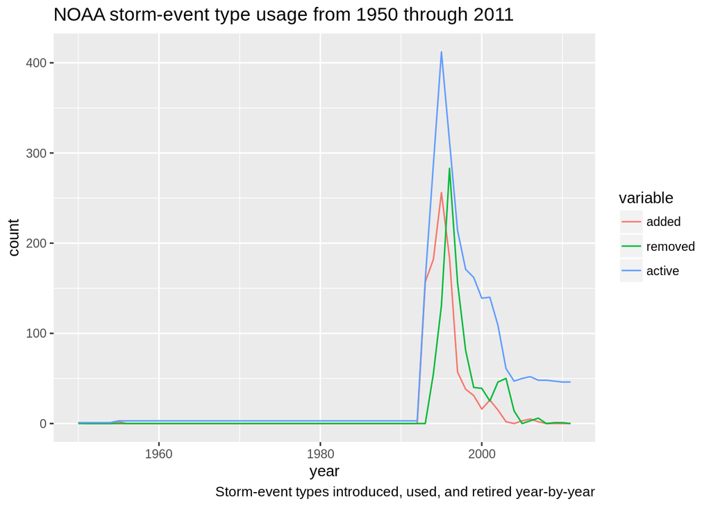

```r
long_updates <- updates %>% melt(id.var = c('year'), value.name = 'count')
ggplot(long_updates, aes(x=year, y=count, color=variable)) +
    geom_line() +
    labs(
        title = "NOAA storm-event type usage from 1950 through 2011",
        caption = "Storm-event types introduced, used, and retired year-by-year"
    )
```

We see that over 400 new event are added between about 1993 and 1995, the majority of which are retired within a few years. The number continues to decline for a decade before stabilizing slightly below 50 around 2005. After 2006, exactly 46 are used in each year.

```r
counts_by_year[2005 <= year,]
```

```
##    year  n
## 1: 2005 46
## 2: 2006 50
## 3: 2007 46
## 4: 2008 46
## 5: 2009 46
## 6: 2010 46
## 7: 2011 46
```

The number of distinct event types used between 2007 and 2011 is 48.

```r
event_types <- unique(dat[(ymd("2007-1-1", tz='Etc/GMT+0') <= begin_datetime), EVTYPE])
sort(event_types)
```

```
##  [1] "ASTRONOMICAL LOW TIDE"    "AVALANCHE"
##  [3] "BLIZZARD"                 "COASTAL FLOOD"
##  [5] "COLD/WIND CHILL"          "DENSE FOG"
##  [7] "DENSE SMOKE"              "DROUGHT"
##  [9] "DUST DEVIL"               "DUST STORM"
## [11] "EXCESSIVE HEAT"           "EXTREME COLD/WIND CHILL"
## [13] "FLASH FLOOD"              "FLOOD"
## [15] "FREEZING FOG"             "FROST/FREEZE"
## [17] "FUNNEL CLOUD"             "HAIL"
## [19] "HEAT"                     "HEAVY RAIN"
## [21] "HEAVY SNOW"               "HIGH SURF"
## [23] "HIGH WIND"                "HURRICANE"
## [25] "ICE STORM"                "LAKE-EFFECT SNOW"
## [27] "LAKESHORE FLOOD"          "LANDSLIDE"
## [29] "LIGHTNING"                "MARINE HAIL"
## [31] "MARINE HIGH WIND"         "MARINE STRONG WIND"
## [33] "MARINE THUNDERSTORM WIND" "RIP CURRENT"
## [35] "SEICHE"                   "SLEET"
## [37] "STORM SURGE/TIDE"         "STRONG WIND"
## [39] "THUNDERSTORM WIND"        "TORNADO"
## [41] "TROPICAL DEPRESSION"      "TROPICAL STORM"
## [43] "TSUNAMI"                  "VOLCANIC ASHFALL"
## [45] "WATERSPOUT"               "WILDFIRE"
## [47] "WINTER STORM"             "WINTER WEATHER"
```

These types are exactly the permitted storm data events listed in table 1, section 2.1.1 of the [National Weather Service Instruction (NWSI) 10-1605](https://d396qusza40orc.cloudfront.net/repdata%2Fpeer2_doc%2Fpd01016005curr.pdf) dated August 17, 2007 (which, provided to us by our instructors, has in its publication date a hint). (Note: `LANDSLIDE` and “Debris Flow” are the same thing.)

### Extracting permitted events

Our usable data is thus limited to the period from 2007 through 2011. We extract this period for further processing.

```r
dat <- dat[(ymd("2007-1-1", tz='Etc/GMT+0') <= begin_datetime),]
```

To simplify troubleshooting we map `EVTYPE` values to names listed in NWSI 10-1605. `LANDSLIDE` maps to “Debris Flow”, `HURRICANE` to “Hurricane (Typhoon)”, and `VOLCANIC ASHFALL` to “Volcanic Ash”. The remainder change capitalization only.

```r
event_transform <- data.frame(rbind(
    c("ASTRONOMICAL LOW TIDE", "Astronomical Low Tide"),
    c("AVALANCHE", "Avalanche"),
    c("BLIZZARD", "Blizzard"),
    c("COASTAL FLOOD", "Coastal Flood"),
    c("COLD/WIND CHILL", "Cold/Wind Chill"),
    c("LANDSLIDE", "Debris Flow"),
    c("DENSE FOG", "Dense Fog"),
    c("DENSE SMOKE", "Dense Smoke"),
    c("DROUGHT", "Drought"),
    c("DUST DEVIL", "Dust Devil"),
    c("DUST STORM", "Dust Storm"),
    c("EXCESSIVE HEAT", "Excessive Heat"),
    c("EXTREME COLD/WIND CHILL", "Extreme Cold/Wind Chill"),
    c("FLASH FLOOD", "Flash Flood"),
    c("FLOOD", "Flood"),
    c("FREEZING FOG", "Freezing Fog"),
    c("FROST/FREEZE", "Frost/Freeze"),
    c("FUNNEL CLOUD", "Funnel Cloud"),
    c("HAIL", "Hail"),
    c("HEAT", "Heat"),
    c("HEAVY RAIN", "Heavy Rain"),
    c("HEAVY SNOW", "Heavy Snow"),
    c("HIGH SURF", "High Surf"),
    c("HIGH WIND", "High Wind"),
    c("HURRICANE", "Hurricane (Typhoon)"),
    c("ICE STORM", "Ice Storm"),
    c("LAKE-EFFECT SNOW", "Lake-Effect Snow"),
    c("LAKESHORE FLOOD", "Lakeshore Flood"),
    c("LIGHTNING", "Lightning"),
    c("MARINE HAIL", "Marine Hail"),
    c("MARINE HIGH WIND", "Marine High Wind"),
    c("MARINE STRONG WIND", "Marine Strong Wind"),
    c("MARINE THUNDERSTORM WIND", "Marine Thunderstorm Wind"),
    c("RIP CURRENT", "Rip Current"),
    c("SEICHE", "Seiche"),
    c("SLEET", "Sleet"),
    c("STORM SURGE/TIDE", "Storm Surge/Tide"),
    c("STRONG WIND", "Strong Wind"),
    c("THUNDERSTORM WIND", "Thunderstorm Wind"),
    c("TORNADO", "Tornado"),
    c("TROPICAL DEPRESSION", "Tropical Depression"),
    c("TROPICAL STORM", "Tropical Storm"),
    c("TSUNAMI", "Tsunami"),
    c("VOLCANIC ASHFALL", "Volcanic Ash"),
    c("WATERSPOUT", "Waterspout"),
    c("WILDFIRE", "Wildfire"),
    c("WINTER STORM", "Winter Storm"),
    c("WINTER WEATHER", "Winter Weather")
))
names(event_transform) <- c("EVTYPE", "event_type")
dat <- merge(dat, event_transform, sort=F)
```

### Transforming property- and crop-damage data

Our property- and crop-damage data appear as fields `PROPDMG/CROPDMG` (numeric) and `PROPDMGEXP/CROPDMGEXP` (character). The former appear to be significands, and the latter exponents that we now explore.

```r
union(unique(dat[, PROPDMGEXP]), unique(dat[, CROPDMGEXP]))
```

```
## [1] "K" "M" "B" "0"
```

The symbol ‘0’ is used once with `PROPDMG` value also zero, so can be assumed to represent 1e0.

```r
dat[(PROPDMGEXP == '0') | (CROPDMGEXP == '0'),]
```

```
##         EVTYPE TIME_ZONE          BGN_DATE    BGN_TIME PROPDMG PROPDMGEXP
## 1: FLASH FLOOD       EST 7/27/2011 0:00:00 08:30:00 PM       0          0
##    CROPDMG CROPDMGEXP FATALITIES INJURIES  timezone      begin_datetime
## 1:       0          K          0        0 Etc/GMT+5 2011-07-27 08:30:00
##     event_type
## 1: Flash Flood
```

Use of symbols ‘K’ (thousands), ‘M’ (millions), and ‘B’ (billions) is consistent with NWSI 10-1605 documentation. We transform exponent symbols to numeric multipliers.

```r
damage_exponent_transform <- data.frame(rbind(
    c("B", 1e9), # Billion
    c("M", 1e6), # Million
    c("K", 1e3), # Thousand
    c("0", 1e0)  # One
))
names(damage_exponent_transform) <- c("PROPDMGEXP", 'property_damage_multiplier')
dat <- merge(dat, damage_exponent_transform, sort=F)
names(damage_exponent_transform) <- c("CROPDMGEXP", 'crop_damage_multiplier')
dat <- merge(dat, damage_exponent_transform, sort=F)
```

We can now synthesize property- and crop-damage values.

```r
dat[, property_damage := PROPDMG * as.numeric(as.character(property_damage_multiplier))]
dat[, crop_damage := CROPDMG * as.numeric(as.character(crop_damage_multiplier))]
```

### Tidying

Our final processing step removes unused fields.

```r
tdy <- dat %>%
    select(
        begin_datetime,
        event_type,
        injuries = INJURIES,
        fatalities = FATALITIES,
        property_damage,
        crop_damage,
    )
```

The remaining tidy fields have the following meanings:

- `event_type`: One of 48 permitted storm-event types listed in NWSI 10-1605 as of August 17, 2007. Type: factor.
- `begin_datetime`: The date and time at start of the event. Type: `POSIXct`.
- `injuries`: The number of direct injuries caused by the event. Type: integer.
- `fatalities`: The number of direct fatalities caused by the event. Type: integer.
- `property_damage`: The dollar amount of direct property damage caused by the event. Type: numeric.
- `crop_damage`: The dollar amount of direct crop damage caused by event. Type: numeric.

Finally, we save the tidy data.

```r
fwrite(tdy, tdy_pth)
```

# Quality assessment

We believe that our usable data cannot answer the original questions. We develop an explanation below, first discussing problems preventing comparative analysis, their solutions, and problems caused by those solutions. The latter prevent answering our original questions. In their place we will pose limited versions our data *can* answer.

In the original data, the number of distinct event types ranges from one to over 400 for any given year. This has at least three causes:

- At different times, very different populations of event types were sampled.
- At different times, very different recording methods were used. At times multiple events of different types were sytematically recorded in single observations. at other times such events were systematically recorded separately.
- There are many examples of events of a single type designated at different times by different spellings.

Different populations and methods at different times result in incomparable data, prevent comparative analysis. Different spellings require extensive by-hand curation during processing. We solve these problems by constraining our dataset to the 48 permitted events listed in NWSI 10-1605, which permits comparative analysis.

Based on this assessment we instead seek answers to the following:

- Across the United States *from 2007 to 2011*, which types of events are most harmful to population health?
- Across the United States *from 2007 to 2011*, which types of events have the greatest economic cost?

# Results

We will first explore average health and economic consequences of different types of storm events, then consider consequences year-by-year, exploring variation from averages consequences.

### Average consequences of storm events

We begin by counting and summing each type of consequence of each storm event type.

```r
counts_by_type <- count(tdy, event_type) %>% data.table()
sums_by_type <- data.table(with(tdy,
    aggregate(
        cbind(injuries, fatalities, property_damage, crop_damage),
        by = list(event_type = event_type),
        sum
    ))
)
counts_and_sums_by_type <- merge(counts_by_type, sums_by_type, sort=F)
```

We define a convenience function to find the top *k* rows by sorting on a column:

```r
k <- 5

top_k_by <- function(data, k, sort_column, ...) {
    sort_column <- rlang::enexpr(sort_column)
    extra_columns <- rlang::quos(...)
    data %>%
        select(!!!extra_columns, !!sort_column) %>%
        do(arrange(., desc(!!sort_column)) %>% head(., k))
}
```

Note above that *k* is “5”. We now find the top-5 worst weather events in terms of each type of consequence (plus “frequency”).

```r
worst_events_by_consequence <- counts_and_sums_by_type %>% {
    list(
        frequency = top_k_by(., k, n, event_type),
        injuries = top_k_by(., k, injuries, event_type),
        fatalities = top_k_by(., k, fatalities, event_type),
        property_damage = top_k_by(., k, property_damage, event_type),
        crop_damage = top_k_by(., k, crop_damage, event_type)
    )
}
worst_events_by_consequence
```

```
## $frequency
##          event_type     n
## 1 Thunderstorm Wind 80665
## 2              Hail 72253
## 3       Flash Flood 19096
## 4             Flood 12450
## 5         High Wind 10390
##
## $injuries
##          event_type injuries
## 1           Tornado     9608
## 2 Thunderstorm Wind     1391
## 3         Lightning      923
## 4    Excessive Heat      880
## 5              Heat      702
##
## $fatalities
##    event_type fatalities
## 1     Tornado        863
## 2 Flash Flood        293
## 3 Rip Current        207
## 4        Heat        182
## 5       Flood        161
##
## $property_damage
##         event_type property_damage
## 1          Tornado     14629323740
## 2            Flood     13969305800
## 3             Hail      6098997600
## 4      Flash Flood      5040672130
## 5 Storm Surge/Tide      4640643000
##
## $crop_damage
##     event_type crop_damage
## 1        Flood  2886110000
## 2 Frost/Freeze   931801000
## 3         Hail   868793000
## 4  Flash Flood   711942000
## 5      Drought   425416000
```

We collect and sort the worst event types in terms of public health, and again of economic damage.

```r
worst_events_for_health <- sort(with(worst_events_by_consequence,
    injuries$event_type %>%
    union(fatalities$event_type)
))
worst_events_for_economy <- sort(with(worst_events_by_consequence,
    property_damage$event_type %>%
    union(crop_damage$event_type)
))
worst_average_events <- sort(union(worst_events_for_health, worst_events_for_economy))
```

On average from 2007 to 2011, the worst event types in terms of public health include Excessive Heat, Flash Flood, Flood, Heat, Lightning, Rip Current, Thunderstorm Wind, Tornado (`worst_events_for_health`), and in terms of economic damage include Drought, Flash Flood, Flood, Frost/Freeze, Hail, Storm Surge/Tide, Tornado (`worst_events_for_economy`).

All together we have 12 worst event types:

```r
worst_average_events
```

```
##  [1] "Drought"           "Excessive Heat"    "Flash Flood"
##  [4] "Flood"             "Frost/Freeze"      "Hail"
##  [7] "Heat"              "Lightning"         "Rip Current"
## [10] "Storm Surge/Tide"  "Thunderstorm Wind" "Tornado"
```

### Year-by-year consequences of storm events

In order to compare years with different overall weather severity, we will normalize and compare annual proportional consequences. We begin by counting and summing each type of consequence of each storm event type for each year, and then convert to proportions.

```r
counts_by_year_and_type <- count(tdy, year = year(with_tz(begin_datetime, 'Etc/GMT')), event_type)
sums_by_year_and_type <- data.table(with(tdy,
    aggregate(
        cbind(injuries, fatalities, property_damage, crop_damage),
        by = list(year = year(with_tz(begin_datetime, 'Etc/GMT')), event_type = event_type),
        sum
    ))
)
counts_and_sums_by_year_and_type <- merge(counts_by_year_and_type, sums_by_year_and_type, sort=F )
counts_and_sums_by_year <- with(
    counts_and_sums_by_year_and_type,
    aggregate(
        cbind(n, injuries, fatalities, property_damage, crop_damage),
        by = list(year = year),
        sum
    )
)
proportions_by_year_and_type <- counts_and_sums_by_year_and_type %>%
    merge(counts_and_sums_by_year, by=c("year"), suffixes=c("", "_annual")) %>%
    transmute(
        year = year,
        event_type = event_type,
        frequency = n/n_annual,
        injuries = injuries/injuries_annual,
        fatalities = fatalities/fatalities_annual,
        property_damage = property_damage/property_damage_annual,
        crop_damage = crop_damage/crop_damage_annual
    )
```

We define another convenience function to find the top *k* rows by sorting on a column, grouping by another column:

```r
k <- 2

group_top_k_by <- function(data, k, sort_column, by_columns, ...) {
    sort_column <- rlang::enexpr(sort_column)
    by_columns <- rlang::enexpr(by_columns)
    if(typeof(by_columns) == "language"){
        by_columns <- rlang::lang_args(by_columns)
    }
    extra_columns <- rlang::quos(...)
    data %>%
        select(!!!by_columns, !!!extra_columns, !!sort_column) %>%
        group_by(!!!by_columns) %>%
        do(arrange(., desc(!!sort_column)) %>% head(., k))
}
```

Note that *k* is now “2”. We find the top-2 worst events in terms of each consequence type, grouped by year.

```r
k <- 2
worst_events_by_year <- proportions_by_year_and_type %>% {
    list(
        frequency = group_top_k_by(., k, frequency, year, event_type),
        injuries = group_top_k_by(., k, injuries, year, event_type),
        fatalities = group_top_k_by(., k, fatalities, year, event_type),
        property_damage = group_top_k_by(., k, property_damage, year, event_type),
        crop_damage = group_top_k_by(., k, crop_damage, year, event_type)
    )
}
worst_year_by_year_for_health <- sort(with(worst_events_by_year,
    injuries$event_type %>%
        union(fatalities$event_type)
))
worst_year_by_year_for_economy <- sort(with(worst_events_by_year,
    property_damage$event_type %>%
        union(crop_damage$event_type)
))
worst_year_by_year_events <- sort(union(
    worst_year_by_year_for_health,
    worst_year_by_year_for_economy
))
worst_events_by_year
```

```
## $frequency
## # A tibble: 10 x 3
## # Groups:   year [5]
##     year event_type        frequency
##    <dbl> <fct>                 <dbl>
##  1  2007 Thunderstorm Wind     0.300
##  2  2007 Hail                  0.294
##  3  2008 Hail                  0.315
##  4  2008 Thunderstorm Wind     0.302
##  5  2009 Thunderstorm Wind     0.292
##  6  2009 Hail                  0.290
##  7  2010 Thunderstorm Wind     0.329
##  8  2010 Hail                  0.227
##  9  2011 Thunderstorm Wind     0.349
## 10  2011 Hail                  0.286
##
## $injuries
## # A tibble: 10 x 3
## # Groups:   year [5]
##     year event_type        injuries
##    <dbl> <fct>                <dbl>
##  1  2007 Tornado             0.301
##  2  2007 Excessive Heat      0.245
##  3  2008 Tornado             0.625
##  4  2008 Thunderstorm Wind   0.0936
##  5  2009 Tornado             0.293
##  6  2009 Lightning           0.148
##  7  2010 Tornado             0.377
##  8  2010 Thunderstorm Wind   0.174
##  9  2011 Tornado             0.791
## 10  2011 Heat                0.0784
##
## $fatalities
## # A tibble: 10 x 3
## # Groups:   year [5]
##     year event_type  fatalities
##    <dbl> <fct>            <dbl>
##  1  2007 Tornado         0.192
##  2  2007 Flash Flood     0.166
##  3  2008 Tornado         0.264
```

[output cut: 24 more lines]

```
## $crop_damage
## # A tibble: 10 x 3
## # Groups:   year [5]
##     year event_type        crop_damage
##    <dbl> <fct>                   <dbl>
##  1  2007 Flood                   0.307
##  2  2007 Frost/Freeze            0.224
##  3  2008 Flood                   0.488
##  4  2008 Flash Flood             0.186
##  5  2009 Hail                    0.672
##  6  2009 Frost/Freeze            0.124
##  7  2010 Flood                   0.619
##  8  2010 Frost/Freeze            0.198
##  9  2011 Flood                   0.232
## 10  2011 Thunderstorm Wind       0.210
```

The worst year-by-year event types in terms of health include Excessive Heat, Flash Flood, Heat, Lightning, Rip Current, Thunderstorm Wind, Tornado, and in terms of economic damage include Flash Flood, Flood, Frost/Freeze, Hail, Hurricane (Typhoon), Storm Surge/Tide, Thunderstorm Wind, Tornado. All together we have 12 event types listed year-by-year:

```r
worst_year_by_year_events
```

```
##  [1] "Excessive Heat"      "Flash Flood"         "Flood"
##  [4] "Frost/Freeze"        "Hail"                "Heat"
##  [7] "Hurricane (Typhoon)" "Lightning"           "Rip Current"
## [10] "Storm Surge/Tide"    "Thunderstorm Wind"   "Tornado"
```

These are similar by not quite the same as the average worst event types. These appear in both lists:

```r
common_events <- intersect(worst_average_events, worst_year_by_year_events)
common_events
```

```
##  [1] "Excessive Heat"    "Flash Flood"       "Flood"
##  [4] "Frost/Freeze"      "Hail"              "Heat"
##  [7] "Lightning"         "Rip Current"       "Storm Surge/Tide"
## [10] "Thunderstorm Wind" "Tornado"
```

Here are the differences. In the average list only:

```r
only_in_average_events <- setdiff(worst_average_events, worst_year_by_year_events)
only_in_average_events
```

```
## [1] "Drought"
```

In the year-by-year list only:

```r
only_in_year_by_year_events <- setdiff(worst_year_by_year_events, worst_average_events)
only_in_year_by_year_events
```

```
## [1] "Hurricane (Typhoon)"
```

Finally, we plot how consequences of each event type vary year-by-year. To display this using a plot panel with *ggplot2*, we’ll need to melt our proportional data, then partition it into consequence types. The result is interesting: only in the case of injuries is it clear that tornadoes are the worst type of event. There otherwise appears to be considerable year-by-year variation in worst event types.

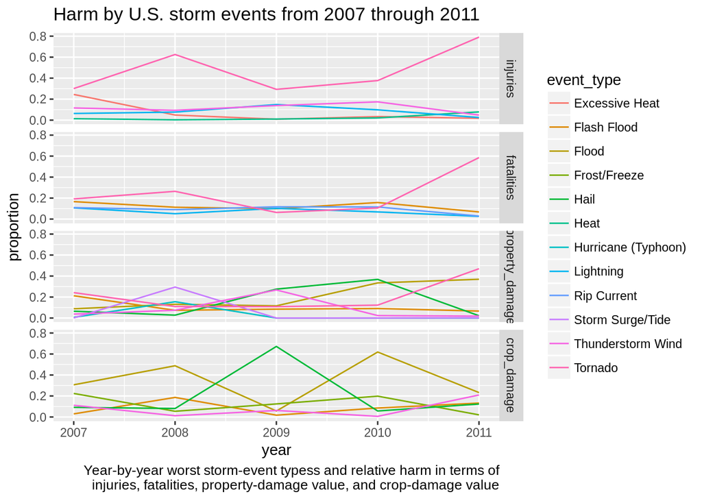

```r
long_proportions_by_year_and_type <- melt(
    proportions_by_year_and_type,
    id.var = c('year', 'event_type'),
    value.name = "proportion"
)

most_harmful_by_year_and_type <- long_proportions_by_year_and_type %>% filter((
    (event_type %in% worst_events_by_year$injuries$event_type)
    &
    (variable == 'injuries')
)|(
    (event_type %in% worst_events_by_year$fatalities$event_type)
    &
    (variable == 'fatalities')
)|(
    (event_type %in% worst_events_by_year$property_damage$event_type)
    &
    (variable == 'property_damage')
)|(
    (event_type %in% worst_events_by_year$crop_damage$event_type)
    &
    (variable == 'crop_damage')
))

ggplot(
    most_harmful_by_year_and_type,
    aes(x=year, y=proportion, color=event_type)
) +
    geom_line() +
    facet_grid(variable ~ .) +
    labs(
        title = "Harm by U.S. storm events from 2007 through 2011",
        caption =
            "Year-by-year worst storm-event typess and relative harm in terms of
            injuries, fatalities, property-damage value, and crop-damage value"
    )
```